# Distribución Binomial Negativa

Téllez Gerardo Rubén

4/2/2022

## V.A

Si $X$ es una variable aleatoria que mide el “número de repeticiones” hasta observar los $r$ ensayos de Bernoulli, diremos que $X$ se distribuye como una Binomial Negativa con parámetros $r$ y $p$.

$$X \sim BN(r, p)$$

donde $p$ es la probabilidad de éxito, y r el número de exitos

- El *dominio* de $X$ será $D_X = \{r, r +1, r+2,...\}$
- La *función de densidad* vendrá dada por

$$f(k) = {k-1\choose r-1} p^r (1-p^{k-r}), k \ge r$$

Número de intentos hasta conseguir r éxitos.

Ajuste de la función de densidad de la binomial.

- La *función de distribución* no tiene expresión analítica.
- *Esperanza* $E(X) = \frac{r}{p}$
- *Varianza* $Var(X) = r\times \frac{1-p}{p^2}$

## El problema de los cigarrillos

Tenemos dos cajas de 20 cigarrillos, una en la izquierda y ptra en la derecha.

Se va fumando independientemente uno a lado de otro. Cuando se ha acabado una caja de cigarrillos, ¿Cuántos quedarán en la otra?

## Función de densidad

Distribución de probabilidad de buscar 5 éxitos con probabilidad 0.5.

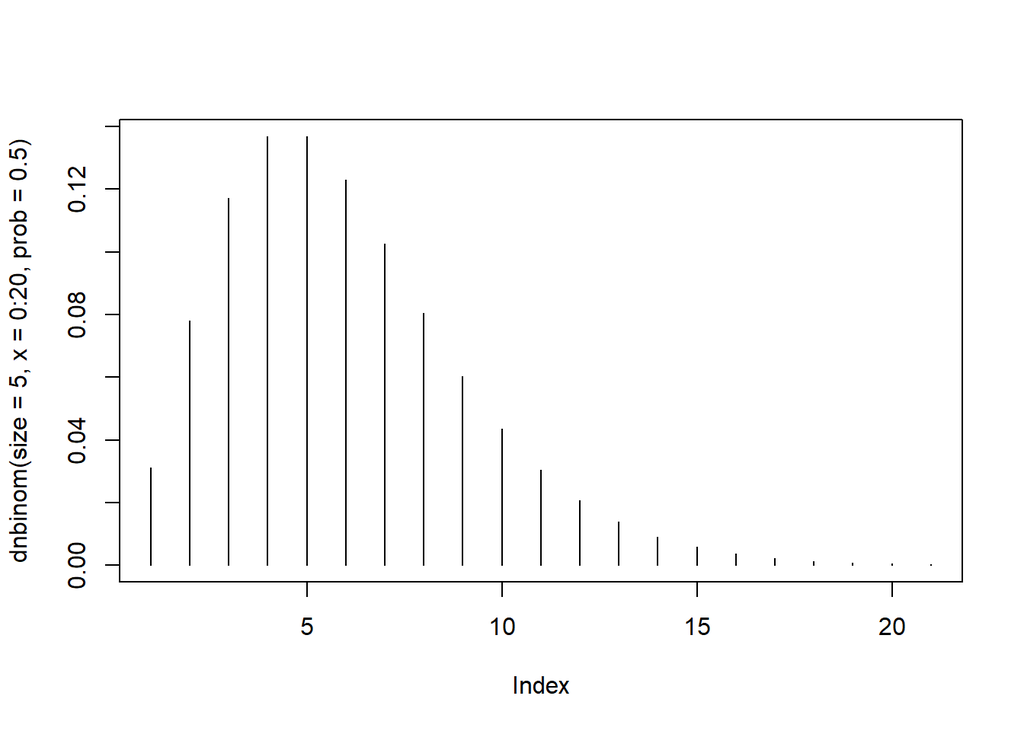

```r
plot(x = dnbinom(size = 5, x = 0:20, prob = 0.5), type="h")
```

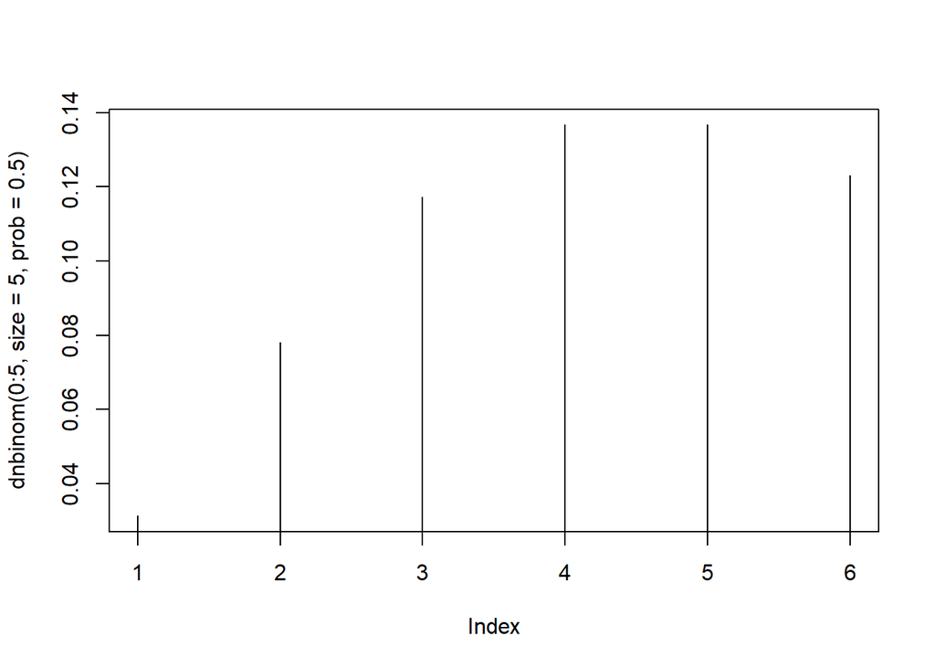

```r
plot(x=dnbinom(0:5,size = 5, prob = 0.5), type="h")
```

## Código

+En R. `dbinom(x, size, prop), pnbinom(1, size, prop), qnbinom(p, size, prop), rbinom(n, size, prop)` donde `size` es el número de casos exitosos y `prob` la probabilidad del éxito.

- En `Python` tenemos las funciones del paquete `scipy.stats.nbinom; pmf(k,n,p), cdf(k,n,p), ppf(q,n,p), rvs(n,p)` donde `n` es el número de casos exitosos y `p` la probabilidad del éxito.

## Distribuciones de probabilidad discreta más importantes.

| Distribución | Instrucción | Parámetros |
| --- | --- | --- |
| Binomial | `binom` | tamaño de la muestra `n` y probabilidad de éxito $p$ |
| Geométrica | `geom` | probabilidad de éxito $p$ |
| Hipergeométerica | `hyper` | N obj, M obj, n total obj |
| Poisson | `pois` | esperanza $\lambda$ |
| Binomial Negativa | `nbinom` | número de éxitos $r$ y probabilidad de éxito $p$ |